# El Atomo

# Repaso

Adaptado de : [Modelos atómicos 3º ESO](https://www.thatquiz.org/es/preview?c=cyafrg37&s=pmrwb0)

```
1. Cientifico que propuso un modelo de átomo no macizo compuesto de NUCLEO y CORTEZA
```

A) Dalton

B) Thomson

C) Rutherford

```
2. En el NUCLEO del átomo hay
```

A) Protones y electrones

B) Electrones

C) Protones

D) Protones y neutrones

```
3. En la CORTEZA del átomo hay
```

C) Electrones en posiciones fijas

D) Electrones en movimiento

```
4. Los PROTONES son partículas subatómicas de carga
```

A) ninguna

B) Positiva

C) Neutros

D) Negativa

```
5. Los PROTONES tienen una masa
```

A) unas 2000 veces mayor que los electrones

C) No tienen masa apreciable

D) son más pequeños que los electrones

```
6. Al número de PROTONES de un átomo se le denomina
```

A) Número isotópico (I)

B) Número másico (A)

C) Número de Avogadro (N)

D) Número atómico (Z)

```
7. Los átomos que tienen IGUAL nº de PROTONES y DISTINTO nº de NEUTRONES se denominan
```

B) Equivalentes

C) Isótopos

D) Gases nobles

```
¿Cuál de estos no es un isótopo del Hidrógeno?
```

A) deuterio B) cuterio C) protio D) tritio

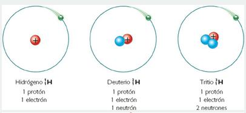

```
9. Los isótopos de un elemento tiene todos el mismo número de
```

A) masa

B) protones y neutrones

C) neutrones

D) protones

```
10. A la suma de PROTONES y NEUTRONES de un átomo se la denomina
```

A) Número protoneutrónico (P)

B) Número nuclear (N)

C) Número másico (A)

D) Número atómico (Z)

```
11. Un elemento que pierde electrones se transforma en
```

A) catión

B) neutro

C) isótopo

D) anión

[output not shown]

B) catión

C) neutro

D) anión

[output not shown]

A) isótopos

B) aniones

C) átomos diferentes

D) cationes

[output not shown]

A) catión

B) imposible

C) isótopo

D) anión

```
15. El modelo atómico que propone que los átomos son indivisibles es el de
```

A) Dalton

B) Rutherford

D) Thompson

```
16. Los rayos de un tubo de vacío que se dirigen hacia el polo positivo se llaman
```

A) catódicos

B) catalíticos

C) católicos

D) neutrones

```
17. El modelo conocido como "pudding de pasas" se debe a
```

A) Bohr

B) Rutherford

C) Thompson

D) Dalton

```
18. Cuando frotamos un objeto se queda con carga eléctrica, eso es porque ...
```

A) cambia neutrones por electrones

B) pierde o gana protones

C) no puede perder ni ganar nada

D) pierde o gana electrones

```
19. El nº de protones que tiene este átomo es
```

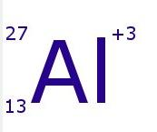

A) 27

B) 14

C) 10

D) 13

```
20. Este átomo tiene
```

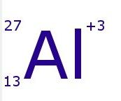

A) 3 electrones más que protones

B) 3 protones más que electrones

C) tres neutrones más que protones

D) todas las subpertículas igual

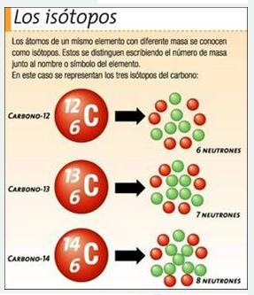

```
21. Estos átomos se diferencian en el nº de
```

A) neutrones

B) electrones

C) en nada

D) protones

```
22. El experimento que se muestra en la figura sirvió para saber que
```

A) que el átomo está formado por electrones

B) que hay partícula en un átomo

C) el átomo estaba formado por un núcleo y una corteza

D) que el átomo no tiene cargas eléctricas

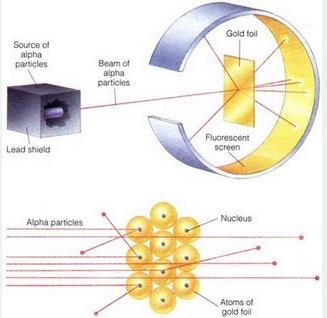

[output not shown]

A) isótopo

B) catión

D) anión

[output not shown]

A) un protón de más

B) igual nº de protones y de neutrones

C) 1 electrón de más

D) diferente nº de neutrones

```
25. Un átomo puede tener en su última capa como máximo
```

A) 8 electrones

B) depende del nº de capa

C) 2 electrones

D) 36 electrones

```
27. ¿Cuántos protones tiene este átomo?
```

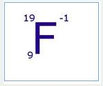

A) 10

B) 9

C) 19

D) 8

```
28. El nº de neutrones que tiene es
```

A) 19 B) 9 C) 10 D) 8

```
29. Indica cuál de estas afirmaciones es cierta
```

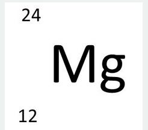

A) tiene el mismo nº de protones que de neutrones

B) tiene 24 protones

C) tiene más neutrones que protones

D) tiene 24 neutrones

```
30. Indica cuál de las siguientes afirmaciones es falsa para este átomo de Argon
```

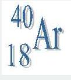

A) tiene 18 protones

B) tiene el mismo nº de protones y de neutrones

C) tiene el mismo nº de protones que de electrones

[figure not shown]

D) tiene 18 neutrones

# OTRAS REFERENCIAS

Fiquizona: [Física y Química 3º ESO](https://sites.google.com/site/fiquizona/fisica-y-quimica-3o-eso#ancla3)

```python
from IPython.display import Image

PATH = "/media/enri/Mi_Proyecto/Apoyo-3-ESO/Fisica y Química  3º ESO/4 El átomo/"
Image(filename = PATH + "isotopo 5.jpeg")
```

[output not shown]